# Exlporatory Data Analysis Continued

```r
library(tidyverse)
library(qqplotr)
library(fastR2)
library(gapminder)
```

Often, a variable either follows or can be approximated by a known theoretical distribution. For example, the data may follow or be well-approximated by a normal distribution. Consider the following:

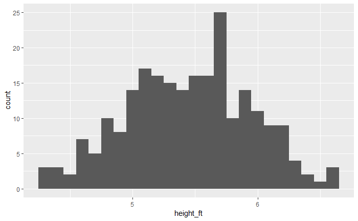

```r
df <- data.frame(height=rnorm(234,mean=66,sd=6))
df <- df %>% mutate(height_ft = height/12)
df %>% ggplot(mapping = aes(x=height_ft)) + geom_histogram(binwidth = 0.1)
```

Let’s convert this to a density.

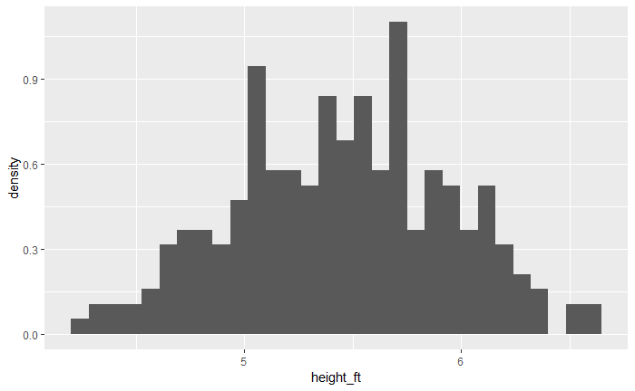

```r
df %>% ggplot(mapping = aes(x=height_ft)) + geom_histogram(aes(y =..density..))
```

We can compute the mean and standard deviation and then overlay a plot of the corresponding normal distribution for comparison.

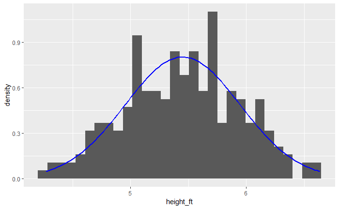

```r
df %>% ggplot(mapping = aes(x=height_ft)) + geom_histogram(aes(y =..density..)) +
  stat_function(fun = dnorm, args = list(mean = mean(df$height_ft), sd = sd(df$height_ft)),color="blue",lwd=1)
```

What do you think? Notice that we used the sample mean and standard deviation to obtain the curve. Since we know the population mean and standard deviation, let’s try it with those as well.

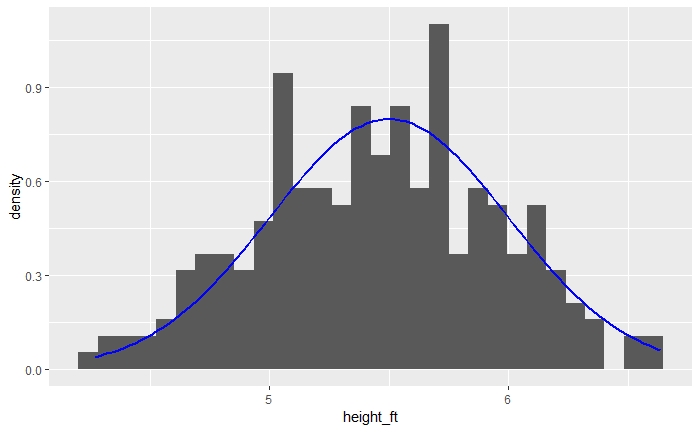

```r
df %>% ggplot(mapping = aes(x=height_ft)) + geom_histogram(aes(y =..density..)) +
  stat_function(fun = dnorm, args = list(mean = 66/12, sd = 6/12),color="blue",lwd=1)
```

Pretty close which makes sense becuase we sampled from that specific distribution. Recall that the density function for the normal distribution is

$f(x) = \frac{1}{\sqrt{2\pi\sigma^2}}e^{-\frac{(x-\mu)^2}{2\sigma^2}}$

where the parameters are the mean $\mu$ and standard deviation $\sigma$. Also recall that the square of the standard deviation $\sigma^2$ is called the **variance**.

Another approach to determine if a variable follows a theoretical distribution is by using a so-called quantile-quantile plot. For example.

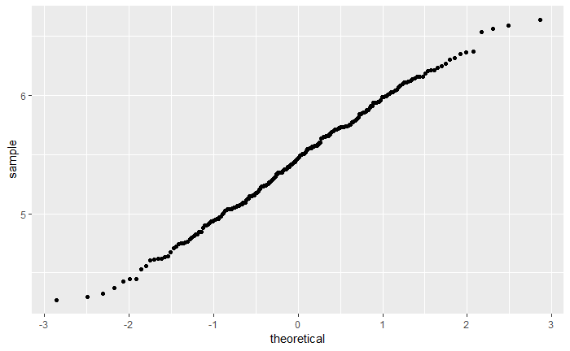

```r
df %>% ggplot( ) + geom_qq(mapping=aes(sample = height_ft))
```

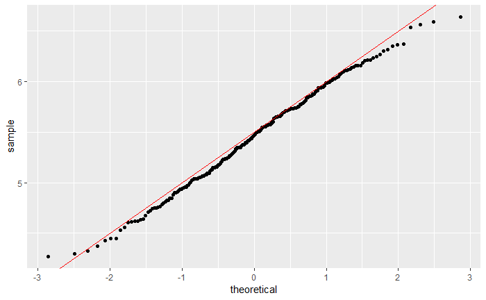

```r
df %>% ggplot( ) + geom_qq(mapping=aes(sample = height_ft)) +
  geom_abline(slope = 6/12,intercept = 66/12,color="red")
```

Since we sampled from a distribution to obtain the data, we know the population mean and standard deviation. What if we use the sample mean and standard deviation?

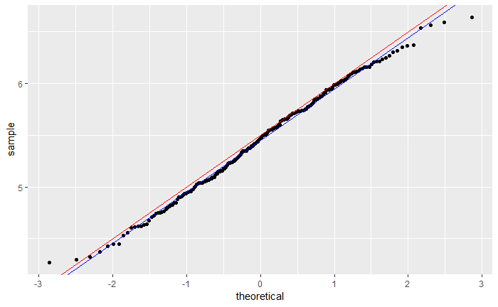

```r
df %>% ggplot( ) + geom_qq(mapping=aes(sample = height_ft)) +
  geom_abline(slope = 6/12,intercept = 66/12,color="red") +
  geom_abline(slope = sd(df$height_ft),intercept = mean(df$height_ft),color="blue")
```

The lines are slightly off but still close because in this case the sample mean and sd are good approximations to the population mean and sd.

The package qqplotr allows us to add more information such as confidence intervals. For example.

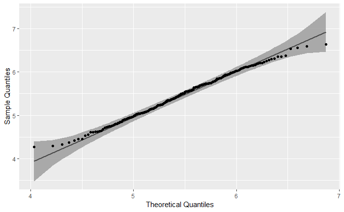

```r
# requires qqplotr package
ggplot(data = df, mapping = aes(sample = height_ft)) +
    stat_qq_band() +
    stat_qq_line() +
    stat_qq_point() +
    labs(x = "Theoretical Quantiles", y = "Sample Quantiles")
```

Let’s apply this to a different data set.

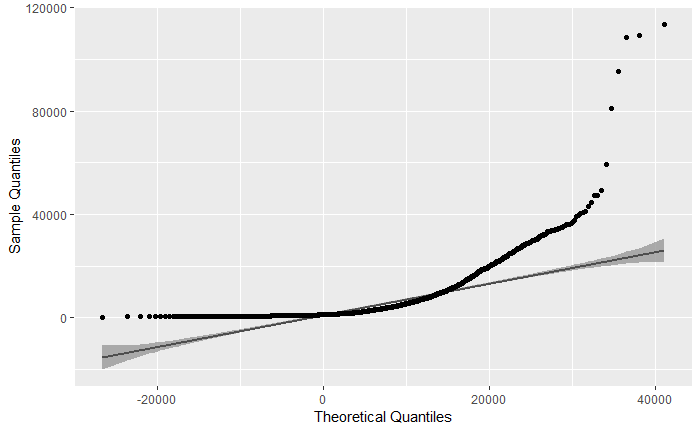

```r
ggplot(data = gapminder, mapping = aes(sample = gdpPercap)) +
    stat_qq_band() +
    stat_qq_line() +
    stat_qq_point() +
    labs(x = "Theoretical Quantiles", y = "Sample Quantiles")
```

Now plot the histogram.

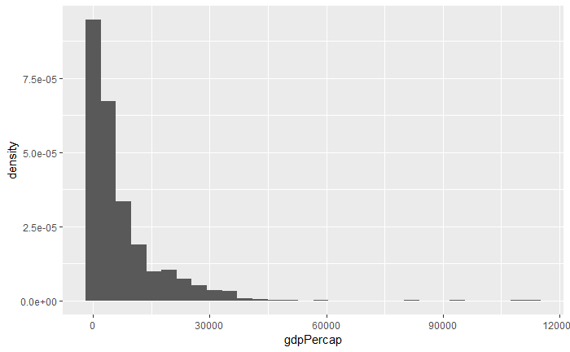

```r
gapminder %>% ggplot(mapping=aes(x=gdpPercap)) + geom_histogram(aes(y =..density..))
```

Definitely does not follow a normal distribution. This is very positively skewed. One last note for now on the normal distribution. One can rescale in order to compare with the *standard normal distribution* which has mean=0 and sd=1. In order to do this, simply subtract the mean from all of the variable values and divide by the sd. We can add this normalized version of a variable to the data frame using mutate and then construct the corresponding qqplot. For example:

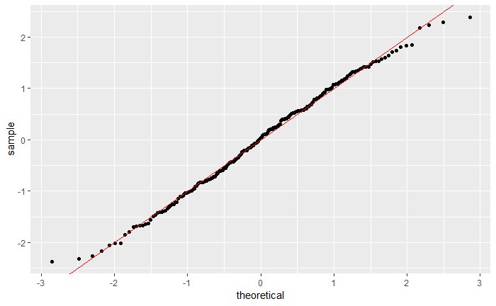

```r
df <- df %>% mutate(height_normalized = (height - mean(height))/sd(height))
df %>% ggplot( ) + geom_qq(mapping=aes(sample = height_normalized)) +
  geom_abline(slope = 1,intercept = 0,color="red")
```

or with confidence intervals:

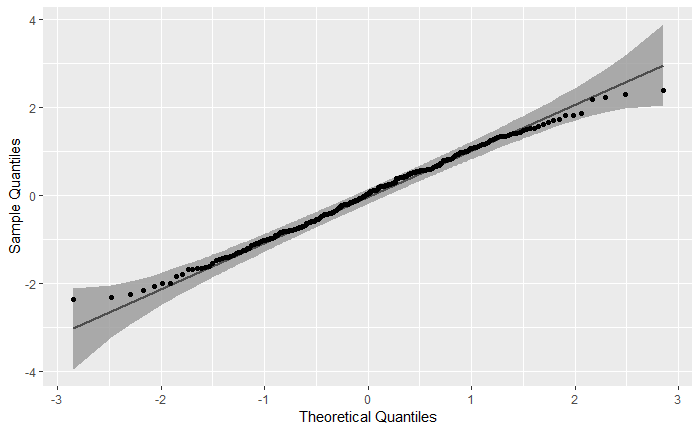

```r
# requires qqplotr package
ggplot(data = df, mapping = aes(sample = height_normalized)) +
    stat_qq_band() +
    stat_qq_line() +
    stat_qq_point() +
    labs(x = "Theoretical Quantiles", y = "Sample Quantiles")
```

**Exercise**: Do this same thing for the gapminder variable gdpPerCap.

# Missing Values

If your data contains questionable values (note that you have to carefully determine what constitutes a questionable value and you should be as transparent as possible about how you do this) for one of more variables, you essentially have three options:

1. Remove the observations (rows) that contain the questionable values.
2. Replace the questionable values with NA.
3. Replace the questionable value with another value that makes more sense.

Of these, 1.generally not the best idea. In order to implement option 3. you need to have a reliable method for determining what another value that makes more sense is. This usually requires a model and will be discussed later. For now, option 2. is probably the best approach. We will discuss this now.

The main question is how do we find and replace all questionable values with NA? The first point is that we should not change the original data set. To avoid doing so we will use mutate to create a modified copy. In order to do this, we can use the ifelse function to replace unusual values with NA. For example

```r
diamonds2 <- diamonds %>%
  mutate(y = ifelse(y < 3 | y > 20, NA, y))
filter(diamonds2,is.na(y))
```

| carat | cut | color | clarity | depth | table | price | x | y | z |
| --- | --- | --- | --- | --- | --- | --- | --- | --- | --- |
| 1.00 | Very Good | H | VS2 | 63.3 | 53 | 5139 | 0.00 | NA | 0.00 |
| 1.14 | Fair | G | VS1 | 57.5 | 67 | 6381 | 0.00 | NA | 0.00 |
| 2.00 | Premium | H | SI2 | 58.9 | 57 | 12210 | 8.09 | NA | 8.06 |
| 1.56 | Ideal | G | VS2 | 62.2 | 54 | 12800 | 0.00 | NA | 0.00 |
| 1.20 | Premium | D | VVS1 | 62.1 | 59 | 15686 | 0.00 | NA | 0.00 |
| 2.25 | Premium | H | SI2 | 62.8 | 59 | 18034 | 0.00 | NA | 0.00 |
| 0.51 | Ideal | E | VS1 | 61.8 | 55 | 2075 | 5.15 | NA | 5.12 |
| 0.71 | Good | F | SI2 | 64.1 | 60 | 2130 | 0.00 | NA | 0.00 |
| 0.71 | Good | F | SI2 | 64.1 | 60 | 2130 | 0.00 | NA | 0.00 |

We see that there are nine rows in diamonds2 that have a y value less than three or greater than 20 and thus the values have been replaced by NA.

**Exercise** Use this technique to replace the questionable salary values in the baseball salaries dataset with NA. **Solution**

```r
url <- "https://raw.githubusercontent.com/jmgraham30/UoSDataSci/master/code/baseballSalaries/Data/Salaries.csv"
bbs <- read_csv(url)
bbs %>% top_n(-5)
```

| yearID | teamID | lgID | playerID | salary |
| --- | --- | --- | --- | --- |
| 1993 | NYA | AL | jamesdi01 | 0 |
| 1993 | NYA | AL | silveda01 | 10900 |
| 1994 | CHA | AL | carych01 | 50000 |
| 1997 | FLO | NL | penaal01 | 50000 |
| 1999 | PIT | NL | martija02 | 0 |

```r
bbs2 <- bbs %>% mutate(salary = ifelse(salary < 50000,NA,salary))
filter(bbs2,is.na(salary))
```

| yearID | teamID | lgID | playerID | salary |
| --- | --- | --- | --- | --- |
| 1993 | NYA | AL | jamesdi01 | NA |
| 1993 | NYA | AL | silveda01 | NA |
| 1999 | PIT | NL | martija02 | NA |

There is an alternative method for obtaining all rows in a data frame that contain missing values. One can use the complete.cases function.

```r
filter(diamonds2,!complete.cases(diamonds2))
```

| carat | cut | color | clarity | depth | table | price | x | y | z |
| --- | --- | --- | --- | --- | --- | --- | --- | --- | --- |
| 1.00 | Very Good | H | VS2 | 63.3 | 53 | 5139 | 0.00 | NA | 0.00 |
| 1.14 | Fair | G | VS1 | 57.5 | 67 | 6381 | 0.00 | NA | 0.00 |
| 2.00 | Premium | H | SI2 | 58.9 | 57 | 12210 | 8.09 | NA | 8.06 |
| 1.56 | Ideal | G | VS2 | 62.2 | 54 | 12800 | 0.00 | NA | 0.00 |
| 1.20 | Premium | D | VVS1 | 62.1 | 59 | 15686 | 0.00 | NA | 0.00 |
| 2.25 | Premium | H | SI2 | 62.8 | 59 | 18034 | 0.00 | NA | 0.00 |
| 0.51 | Ideal | E | VS1 | 61.8 | 55 | 2075 | 5.15 | NA | 5.12 |
| 0.71 | Good | F | SI2 | 64.1 | 60 | 2130 | 0.00 | NA | 0.00 |
| 0.71 | Good | F | SI2 | 64.1 | 60 | 2130 | 0.00 | NA | 0.00 |

Let’s look at this for another example.

```r
examp_df <- data.frame(one=c(1,2,NA,3,4,NA),two=c(NA,"Bill","Martha","Steve",NA,"Mary"))
filter(examp_df,complete.cases(examp_df))
```

| one | two |
| --- | --- |
| 2 | Bill |
| 3 | Steve |

```r
filter(examp_df,!complete.cases(examp_df))
```

| one | two |
| --- | --- |
| 1 | NA |
| NA | Martha |
| 4 | NA |
| NA | Mary |

This can be very useful.

**Exercise** Find all the rows in the baseball salary data frame where you have replaced salary values with NA. **Solution**

```r
filter(bbs2,!complete.cases(bbs2))
```

| yearID | teamID | lgID | playerID | salary |
| --- | --- | --- | --- | --- |
| 1993 | NYA | AL | jamesdi01 | NA |
| 1993 | NYA | AL | silveda01 | NA |
| 1999 | PIT | NL | martija02 | NA |

Notice what happens if we make a plot where one of the aesthetics is y.

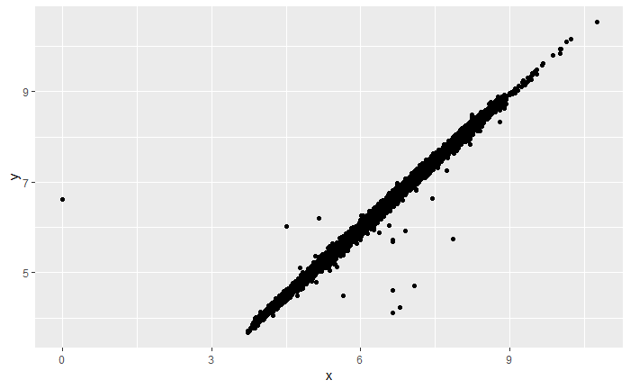

```r
ggplot(data = diamonds2, mapping = aes(x = x, y = y)) +
  geom_point()
```

Notice that ggplot informs us that missing values are present and have been excluded from the plot.

Often one would like to understand what makes observations with missing values different to observations with recorded values. For example, in nycflights13::flights, missing values in the dep_time variable indicate that the flight was cancelled. So you might want to compare the scheduled departure times for cancelled and non-cancelled times. You can do this by making a new variable with is.na().

```r
nycflights13::flights %>%
  mutate(
    cancelled = is.na(dep_time),
    sched_hour = sched_dep_time %/% 100,
    sched_min = sched_dep_time %% 100,
    sched_dep_time = sched_hour + sched_min / 60
  ) %>%
  ggplot(mapping = aes(sched_dep_time)) +
    geom_freqpoly(mapping = aes(colour = cancelled), binwidth = 1/4)
```

**Exercise** What happens to missing values in a histogram? What happens to missing values in a bar chart? Why is there a difference?

**Exercise** What does na.rm = TRUE do in mean() and sum()?

# Relationship Between Variables (Covariation)

If variation describes the behavior within a variable, covariation describes the behavior between variables. **Covariation** is the tendency for the values of two or more variables to vary together in a related way. As we hinted at before, how you visualize covariation depends on if the variables are all continuous or if some are categorical.

## Case 1: A categorical and a continuous variable

Suppose we want to see how the price of a diamond varies with its quality, then one could use the following plot:

```r
ggplot(data = diamonds, mapping = aes(x = price)) +
  geom_freqpoly(mapping = aes(colour = cut), binwidth = 500)
```

```r
ggplot(data = diamonds, mapping = aes(x = price, y = ..density..)) +
  geom_freqpoly(mapping = aes(colour = cut), binwidth = 500)
```

Another way to look at the same information is by using boxplots. For example,

```r
ggplot(data = diamonds, mapping = aes(x = cut, y = price)) +
  geom_boxplot()
```

or

```r
ggplot(data = diamonds, mapping = aes(x = cut, y = price,color=cut)) +
  geom_boxplot()
```

How does ggplot know the order in which to place the cut categories along the x-axis?

```r
head(diamonds)
```

```r
ggplot(data = mpg, mapping = aes(x = class, y = hwy)) +
  geom_boxplot()
```

What if we want to order the values along the x-axis differently? This can be done easily with the reorder function. For example

```r
ggplot(data = mpg) +
  geom_boxplot(mapping = aes(x = reorder(class, hwy, FUN = median), y = hwy))
```

## Case 2: Two categorical variables

To visualise the covariation between categorical variables, youâll need to count the number of observations for each combination. One way to do that is to rely on the built-in geom_count():

```r
ggplot(data = diamonds) +
  geom_count(mapping = aes(x = cut, y = color))
```

```r
diamonds %>% count(cut,color)
```

We can actually use this to construct another type of plot:

```r
diamonds %>%
  count(color, cut) %>%
  ggplot(mapping = aes(x = color, y = cut)) +
    geom_tile(mapping = aes(fill = n))
```

or

```r
diamonds %>%
  count(color, cut) %>%
  ggplot(mapping = aes(x = color, y = cut)) +
    geom_tile(mapping = aes(fill = n)) +
  coord_flip()
```

## Case 3: Two continuous variables

We have already seen scatterplots which are the most common way to visualize the covariation between two continuous variables. For example,

```r
ggplot(data = diamonds) +
  geom_point(mapping = aes(x = carat, y = price))
```

What are some of the problems that may arise in using such a plot? What will happen as the number of observations increases?

One option is to use shading like this,

```r
ggplot(data = diamonds) +
  geom_point(mapping = aes(x = carat, y = price), alpha = 1 / 100)
```

Here are a couple of other interesting options.

```r
ggplot(data = diamonds) +
  geom_bin2d(mapping = aes(x = carat, y = price))
```

```r
library(hexbin)
ggplot(data = diamonds) +
  geom_hex(mapping = aes(x = carat, y = price))
```

Basically what these do is to bin each of the two variables in order to create a plot analogous to what we did when we compared cut and color with the tile plot.

Next, we will explore tidy data.